# Demographic Change in Germany—A Case Study

Clemens S. Heithecker

2 July 2021

A low birth rate and rising life expectancy are fueling demographic change in Germany. These trends pose economic challenges such as a dwindling labor force and the underfunding of social security systems. As a result, lawmakers must re-evaluate existing public policies and design new solutions. This case study provides data visualizations supporting the exploration and evaluation of policy options to solve these demographic problems.

The project’s source files as well as references are published on the [project’s GitHub repository](https://github.com/clemensheithecker/demographic-change-germany).

## Libraries

```r
library(here)
library(maps)
library(readxl)
library(tidyverse)
```

## Global Styles and Colors

I created two color pallets as lists which I referenced when styling the graphs.

```r
colors_primary = list(
  very_light_blue = "#DBEAFE",
  light_blue = "#93C5FD",
  blue = "#3B82F6",
  dark_blue = "#1D4ED8",
  very_dark_blue = "#1E3A8A",
  very_light_gray = "#E4E4E7",
  light_gray = "#A1A1AA",
  dark_gray = "#52525B"
)

colors_secondary = list(
  title = "#18181B",
  text = "#3F3F46",
  line = "#D4D4D4",
  caption = "#71717A"
)
```

## Total Fertility Rate in Germany

A visualization of the average live births per woman over time. The data is grouped by region: Federal Republic of Germany, former territory of the Federal Republic, former territory of East Germany.

### Reading and Cleaning Data

Reading the .csv file with semicolon delimeter using readr’s *read_delim* function.

```r
fertility_rate <-
  read_delim(
    file = here("data", "completed-cohort-fertility.csv"),
    delim = ";",
    escape_double = FALSE,
    col_names = c("Year",
                  "Germany",
                  "Old Federal States",
                  "New Federal States"),
    col_types = "innn",
    locale = locale(
      decimal_mark = ".",
      grouping_mark = ",",
      encoding = "UTF-8"
    ),
    trim_ws = TRUE,
    skip = 1
  )

tail(fertility_rate)
```

| Year | Germany | Old Federal States | New Federal States |
| --- | --- | --- | --- |
| 2014 | 1.475 | 1.470 | 1.544 |
| 2015 | 1.502 | 1.503 | 1.561 |
| 2016 | 1.592 | 1.596 | 1.640 |
| 2017 | 1.569 | 1.577 | 1.614 |
| 2018 | 1.565 | 1.578 | 1.598 |
| 2019 | 1.540 | 1.557 | 1.562 |

Reshape data frame to long format. Having a column for every variable and a row for every observation makes it easier to visualize the data using *ggplot2*.

```r
fertility_rate_long <- fertility_rate %>%
  gather(key = "Country/Region",
         value = "Total Fertility Rate", -"Year")

tail(fertility_rate_long)
```

| Year | Country/Region | Total Fertility Rate |
| --- | --- | --- |
| 2014 | New Federal States | 1.544 |
| 2015 | New Federal States | 1.561 |
| 2016 | New Federal States | 1.640 |
| 2017 | New Federal States | 1.614 |
| 2018 | New Federal States | 1.598 |
| 2019 | New Federal States | 1.562 |

Change the factor order. This changes the order of the labels in the legend of the plot. Additionally, give factors more descriptive names.

```r
# change factor order
fertility_rate_long$`Country/Region` <-
  factor(
    fertility_rate_long$`Country/Region`,
    c("New Federal States",
      "Old Federal States",
      "Germany")
  )

# rename factors
fertility_rate_long$`Country/Region` <- recode(
  fertility_rate_long$`Country/Region`,
  `New Federal States` = "New Federal States (East Germany until 1989)",
  `Old Federal States`  = "Old Federal States (West Germany until 1989)",
  `Germany` = "Germany"
)

levels(fertility_rate_long$`Country/Region`)
```

```
## [1] "New Federal States (East Germany until 1989)"
## [2] "Old Federal States (West Germany until 1989)"
## [3] "Germany"
```

### Plot Data

Plotting the data as a line plot.

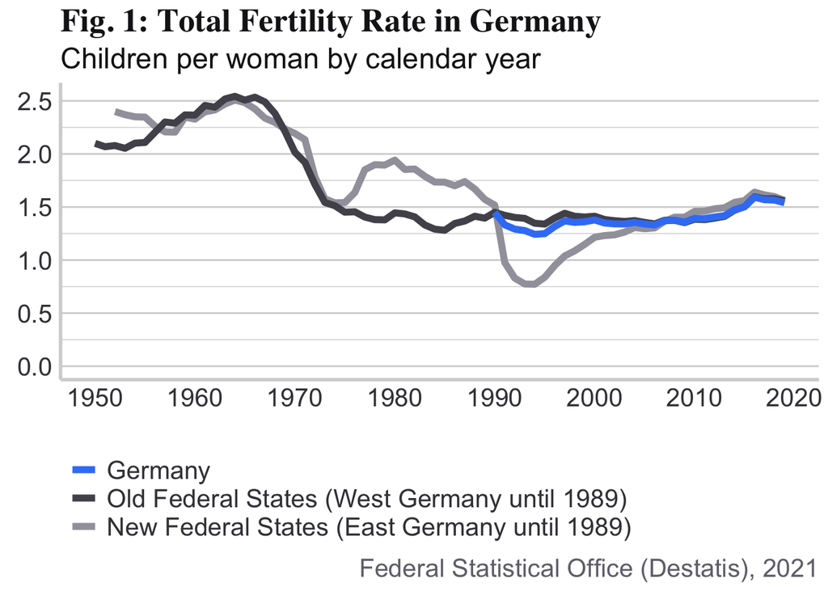

```r
ggplot(
  data = fertility_rate_long,
  mapping = aes(x = Year,
                y = `Total Fertility Rate`,
                color = `Country/Region`)
) +
  geom_line(size = 2) +
  # starting y-axis from y=0
  expand_limits(y = 0) +
  # setting custom color scale
  scale_color_manual(
    values = c(
      colors_primary$light_gray,
      colors_primary$dark_gray,
      colors_primary$blue
    )
  ) +
  # setting x-axis scale from 1950 to 2020 in 10-year intervals
  scale_x_continuous(breaks = seq(from = 1950, to = 2020, by = 10)) +
  # setting y-axis scale
  scale_y_continuous(breaks = seq(from = 0, to = 2.5, by = 0.5)) +
  labs(
    title = "Fig. 1: Total Fertility Rate in Germany",
    subtitle = "Children per woman by calendar year",
    x = element_blank(),
    y = element_blank(),
    caption = "Federal Statistical Office (Destatis), 2021"
  ) +
  # reverse order of legend
  guides(color = guide_legend(reverse = TRUE)) +
  # Theme And Styles
  theme_minimal() +
  theme(
    axis.line = element_line(
      color = colors_secondary$line,
      size = 1,
      linetype = "solid"
    ),
    axis.text = element_text(color = colors_secondary$text,
                             size = rel(1.4)),
    legend.direction = "vertical",
    legend.justification = "left",
    legend.position = "bottom",
    legend.text = element_text(color = colors_secondary$text,
                               size = rel(1.4)),
    legend.title = element_blank(),
    panel.grid = element_line(color = colors_secondary$line),
    panel.grid.major.x = element_blank(),
    panel.grid.minor.x = element_blank(),
    plot.caption = element_text(color = colors_secondary$caption,
                                size = rel(1.4)),
    plot.subtitle = element_text(color = colors_secondary$title,
                                 size = rel(1.6)),
    plot.title = element_text(
      color = colors_secondary$title,
      size = rel(1.8),
      face = "bold",
      family = "serif"
    )
  )
```

Save figure as .png file.

```r
ggsave(
  "figures/plot_1_fertility_rate.png",
  width = 24,
  height = 18,
  units = "cm",
  dpi = "retina",
  bg = "white"
)
```

## At-Risk-of-Poverty Rate of Families

A visual comparison of the at-risk-of-poverty rate by household type. The rate is measured against the federal median income.

### Reading and Cleaning Data

Reading the .xlsx file readxl’s *read_excel* function.

```r
poverty_risk_rate <-
  read_excel(
    "data/Armutsgefaehrdungsquote-nach-Haushaltstyp.xlsx",
    # translate column names from German to English
    col_names = c(
      "Year",
      "1-Person Household",
      "2 Adults without Children",
      "Other Household without Children",
      "1 Adult with Children",
      "2 Adults with 1 Child",
      "2 Adults with 2 Children",
      "2 Adults with 3+ Children",
      "Other Household with Children"
    ),
    col_types = rep("numeric", times = 9),
    skip = 3,
    n_max = 15
  )
```

Subset data to select relevant columns of households with children and the most recent year of the dataset, 2019.

```r
poverty_risk_rate <- poverty_risk_rate %>%
  filter(Year == 2019) %>%
  select(
    `Year`,
    `1 Adult with Children`,
    `2 Adults with 1 Child`,
    `2 Adults with 2 Children`,
    `2 Adults with 3+ Children`,
    `Other Household with Children`
  )

str(poverty_risk_rate)
```

```
## tibble [1 × 6] (S3: tbl_df/tbl/data.frame)
##  $ Year                         : num 2019
##  $ 1 Adult with Children        : num 42.7
##  $ 2 Adults with 1 Child        : num 8.8
##  $ 2 Adults with 2 Children     : num 11
##  $ 2 Adults with 3+ Children    : num 30.9
##  $ Other Household with Children: num 19.3
```

Reshape data frame to long format.

```r
poverty_risk_rate_long <- poverty_risk_rate %>%
  gather(key = "Household Type",
         value = "Poverty Risk Rate", -"Year")

poverty_risk_rate_long
```

| Year | Household Type | Poverty Risk Rate |
| --- | --- | --- |
| 2019 | 1 Adult with Children | 42.7 |
| 2019 | 2 Adults with 1 Child | 8.8 |
| 2019 | 2 Adults with 2 Children | 11.0 |
| 2019 | 2 Adults with 3+ Children | 30.9 |
| 2019 | Other Household with Children | 19.3 |

Change the factor order. This changes the order of the labels in the legend of the plot.

```r
poverty_risk_rate_long$`Household Type` <-
  factor(
    poverty_risk_rate_long$`Household Type`,
    c(
      "Other Household with Children",
      "1 Adult with Children",
      "2 Adults with 3+ Children",
      "2 Adults with 2 Children",
      "2 Adults with 1 Child"
    )
  )

levels(poverty_risk_rate_long$`Household Type`)
```

```
## [1] "Other Household with Children" "1 Adult with Children"
## [3] "2 Adults with 3+ Children"     "2 Adults with 2 Children"
## [5] "2 Adults with 1 Child"
```

### Plot Data

Plotting the data as a bar plot.

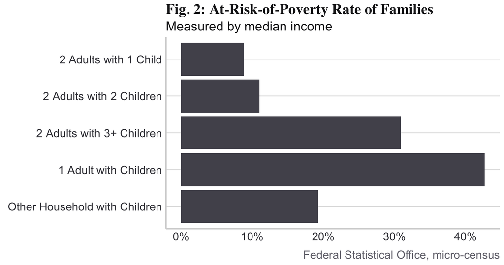

```r
ggplot(data = poverty_risk_rate_long,
       mapping = aes(x = `Poverty Risk Rate`,
                     y = `Household Type`)) +
  geom_col(fill = colors_primary$dark_gray) +
  # format x-axis scale as percentage
  scale_x_continuous(
    labels = function(x)
      paste0(x, "%")
  ) +
  labs(
    title = "Fig. 2: At-Risk-of-Poverty Rate of Families",
    subtitle = "Measured by median income",
    x = element_blank(),
    y = element_blank(),
    caption = "Federal Statistical Office, micro-census"
  ) +
  theme_minimal() +
  theme(
    axis.line = element_line(
      color = colors_secondary$line,
      size = 1,
      linetype = "solid"
    ),
    axis.text = element_text(color = colors_secondary$text,
                             size = rel(1.4)),
    panel.grid = element_line(color = colors_secondary$line),
    panel.grid.major.x = element_blank(),
    panel.grid.minor.x = element_blank(),
    plot.caption = element_text(color = colors_secondary$caption,
                                size = rel(1.4)),
    plot.subtitle = element_text(color = colors_secondary$title,
                                 size = rel(1.6)),
    plot.title = element_text(
      color = colors_secondary$title,
      size = rel(1.8),
      face = "bold",
      family = "serif"
    ),
  )
```

Save figure as .png file.

```r
ggsave(
  "figures/plot_2_poverty_risk_rate.png",
  width = 24,
  height = 18,
  units = "cm",
  dpi = "retina",
  bg = "white"
)
```

## Total Fertility Rates in Europe

A map visualization to compare the total fertility rates between countries of the European Union and the European Free Trade Association.

### Reading and Cleaning Data

Reading the .csv file using readr’s *read_csv* function.

```r
fertility_rate_eu <- read_csv(
  file = "data/estat_tps00199.csv",
  col_names = c("Country Code", seq(
    from = 2008, to = 2019, by = 1
  )),
  col_types = "cnnnnnnnnnnnn",
  na = ":",
  trim_ws = TRUE,
  skip = 1
)

head(fertility_rate_eu)
```

| Country Code | 2008 | 2009 | 2010 | 2011 | 2012 | 2013 | 2014 | 2015 | 2016 | 2017 | 2018 | 2019 |
| --- | --- | --- | --- | --- | --- | --- | --- | --- | --- | --- | --- | --- |
| A;TOTFERRT;AD | 1.25 | 1.19 | 1.27 | NA | NA | NA | NA | NA | NA | NA | NA | NA |
| A;TOTFERRT;AL | 1.58 | 1.63 | 1.63 | 1.65 | 1.71 | 1.73 | 1.73 | 1.59 | 1.54 | 1.48 | 1.37 | NA |
| A;TOTFERRT;AM | 1.43 | 1.53 | NA | NA | NA | NA | NA | 1.62 | 1.62 | 1.56 | 1.57 | 1.60 |
| A;TOTFERRT;AT | 1.42 | 1.39 | 1.44 | 1.43 | 1.44 | 1.44 | 1.46 | 1.49 | 1.53 | 1.52 | 1.47 | 1.46 |
| A;TOTFERRT;AZ | 1.90 | 1.82 | 1.92 | NA | 2.00 | 1.98 | 1.97 | 1.94 | 1.90 | 1.75 | 1.73 | 1.81 |
| A;TOTFERRT;BE | 1.85 | 1.84 | 1.86 | 1.81 | 1.80 | 1.76 | 1.74 | 1.70 | 1.68 | 1.65 | 1.62 | 1.58 |

Clean up the ‘Country Code’ column by removing the leading string ‘A;TOTFERRT;’ of every entry.

```r
fertility_rate_eu <- fertility_rate_eu %>%
  mutate(`Country Code` = sub("A;TOTFERRT;", "", `Country Code`))

head(fertility_rate_eu)
```

| Country Code | 2008 | 2009 | 2010 | 2011 | 2012 | 2013 | 2014 | 2015 | 2016 | 2017 | 2018 | 2019 |
| --- | --- | --- | --- | --- | --- | --- | --- | --- | --- | --- | --- | --- |
| AD | 1.25 | 1.19 | 1.27 | NA | NA | NA | NA | NA | NA | NA | NA | NA |
| AL | 1.58 | 1.63 | 1.63 | 1.65 | 1.71 | 1.73 | 1.73 | 1.59 | 1.54 | 1.48 | 1.37 | NA |
| AM | 1.43 | 1.53 | NA | NA | NA | NA | NA | 1.62 | 1.62 | 1.56 | 1.57 | 1.60 |
| AT | 1.42 | 1.39 | 1.44 | 1.43 | 1.44 | 1.44 | 1.46 | 1.49 | 1.53 | 1.52 | 1.47 | 1.46 |
| AZ | 1.90 | 1.82 | 1.92 | NA | 2.00 | 1.98 | 1.97 | 1.94 | 1.90 | 1.75 | 1.73 | 1.81 |
| BE | 1.85 | 1.84 | 1.86 | 1.81 | 1.80 | 1.76 | 1.74 | 1.70 | 1.68 | 1.65 | 1.62 | 1.58 |

Define lists of countries which are part of the European Union (EU) and the European Free Trade Association (EFTA). The lists include the ISO 3166-1 Alpha-2 code country abbreviation as key as well as the full country name as correspondig value. The lists are from the following sources: [Member state of the European Union—Wikipedia](https://en.wikipedia.org/wiki/Member_state_of_the_European_Union), [European Free Trade Association—Wikipedia](https://en.wikipedia.org/wiki/European_Free_Trade_Association), and [ISO 3166-1—Wikipedia](https://en.wikipedia.org/wiki/ISO_3166-1)

```r
eu_countries <- list(
  "BE" = "Belgium",
  "BG" = "Bulgaria",
  "CZ" = "Czechia",
  "DK" = "Denmark",
  "DE" = "Germany",
  "EE" = "Estonia",
  "IE" = "Ireland",
  "EL" = "Greece",
  "ES" = "Spain",
  "FR" = "France",
  "HR" = "Croatia",
  "IT" = "Italy",
  "CY" = "Cyprus",
  "LV" = "Latvia",
  "LT" = "Lithuania",
  "LU" = "Luxembourg",
  "HU" = "Hungary",
  "MT" = "Malta",
  "NL" = "Netherlands",
  "AT" = "Austria",
  "PL" = "Poland",
  "PT" = "Portugal",
  "RO" = "Romania",
  "SI" = "Slovenia",
  "SK" = "Slovakia",
  "FI" = "Finland",
  "SE" = "Sweden",
  "UK" = "United Kingdom"
)

efta_countries <- list(
  "IS" = "Iceland",
  "LI" = "Liechtenstein",
  "NO" = "Norway",
  "CH" = "Switzerland"
)
```

Select only the latest time period of the time series data, 2019, and rename the column to ‘Fertility Rate’. Add another column ‘region’ with the full country name.

```r
fertility_rate_eu <- fertility_rate_eu %>%
  select(`Country Code`, `2019`) %>%
  rename(`Fertility Rate` = `2019`) %>%
  filter(`Country Code` %in% c(names(eu_countries), names(efta_countries))) %>%
  mutate(region = as.character(append(eu_countries, efta_countries)[`Country Code`]))

head(fertility_rate_eu)
```

| Country Code | Fertility Rate | region |
| --- | --- | --- |
| AT | 1.46 | Austria |
| BE | 1.58 | Belgium |
| BG | 1.58 | Bulgaria |
| CH | 1.48 | Switzerland |
| CY | 1.33 | Cyprus |
| CZ | 1.71 | Czechia |

Prepare map data by downloading maps’ world data and joining it with the fertility_rate_eu dataframe.

```r
eu_map <- map_data("world")

eu_fertility_map <- left_join(eu_map, fertility_rate_eu, by = "region")

tail(eu_fertility_map)
```

|  | long | lat | group | order | region | subregion | Country Code | Fertility Rate |
| --- | --- | --- | --- | --- | --- | --- | --- | --- |
| 99333 | 12.43916 | 41.89839 | 1627 | 100959 | Vatican | enclave | NA | NA |
| 99334 | 12.43838 | 41.90620 | 1627 | 100960 | Vatican | enclave | NA | NA |
| 99335 | 12.43057 | 41.90547 | 1627 | 100961 | Vatican | enclave | NA | NA |
| 99336 | 12.42754 | 41.90073 | 1627 | 100962 | Vatican | enclave | NA | NA |
| 99337 | 12.43057 | 41.89756 | 1627 | 100963 | Vatican | enclave | NA | NA |
| 99338 | 12.43916 | 41.89839 | 1627 | 100964 | Vatican | enclave | NA | NA |

### Plot Data

Plotting the data as a map.

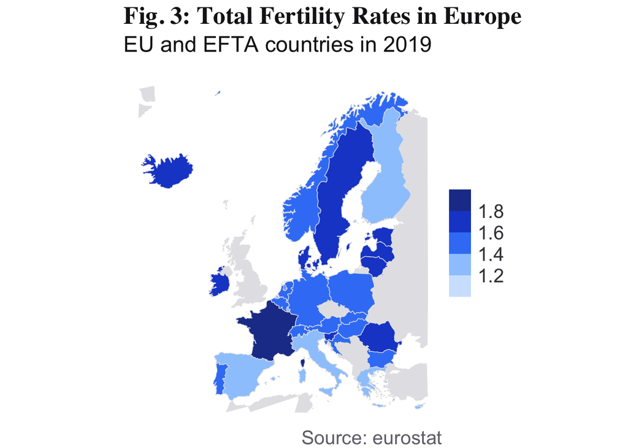

```r
ggplot(data = eu_fertility_map, mapping = aes(x = long, y = lat)) +
  geom_polygon(
    mapping = aes(group = group, fill = `Fertility Rate`),
    size = 0.25,
    color = colors_primary$very_light_gray
  ) +

  xlim(-25, 35) +
  ylim(34, 71.5) +
  coord_map() +
  theme_void() +
  scale_fill_stepsn(
    colors = c(
      colors_primary$very_light_blue,
      colors_primary$light_blue,
      colors_primary$blue,
      colors_primary$dark_blue,
      colors_primary$very_dark_blue
    ),
    na.value = colors_primary$very_light_gray
  ) +
  labs(
    title = "Fig. 3: Total Fertility Rates in Europe",
    subtitle = "EU and EFTA countries in 2019",
    x = element_blank(),
    y = element_blank(),
    caption = "Source: eurostat"
  ) +
  theme(
    legend.text = element_text(color = colors_secondary$text, size = rel(1.4)),
    legend.title = element_blank(),
    plot.caption = element_text(color = colors_secondary$caption,
                                size = rel(1.4)),
    plot.subtitle = element_text(color = colors_secondary$title,
                                 size = rel(1.6),),
    plot.title = element_text(
      color = colors_secondary$title,
      size = rel(1.8),
      face = "bold",
      family = "serif"
    )
  )
```

Save figure as .png file.

```r
ggsave(
  "figures/plot_3_fertility_rate_eu.png",
  height = 18,
  units = "cm",
  dpi = "retina",
  bg = "white"
)
```